## 1) Data visualization: flights at ABIA

### Question:

**What is the best month to fly to minimize arriving delays, and does this change by airline?**

### Graph 1:

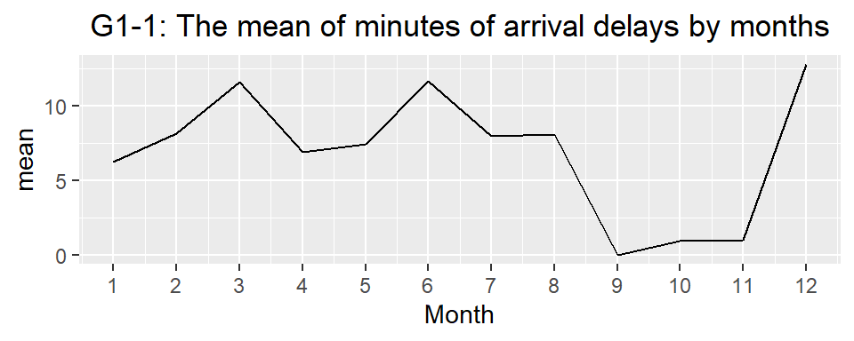

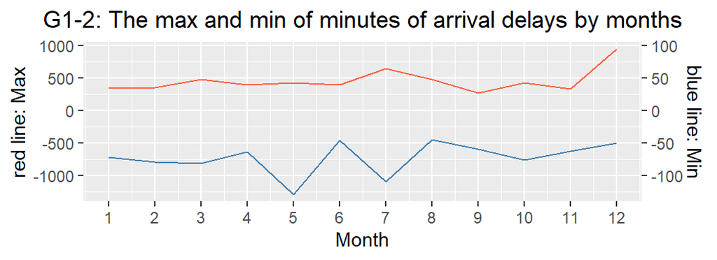

### Comment on Graph 1:

We can see from G1-1 of Graph 1 that the highest average of the arrival delays by month is December, and that on September, October and November are low compared to other months. Also, The G1-2 graph shows that the month of the highest arrival delay is December, and that of the lowest is May.

### Discussion on Graph 1:

So, from these results, we can estimate the following points. First, the number of arrival delays probably is caused by the number of passengers at ABIA. For example, a low number of arrival delays means fewer passengers. Therefore, from September to November, the number of passengers at ABIA might be lower than that of the other months. This is because students in Austin start their semesters and do not use the airport to go out of the city. In contrast, in December, the number of passengers will increase drastically; for example, they fly to their home countries and other cities in holidays.

Focusing on the max and min of the number, we can easily understand why December has the highest number of arrival delays. However, we also need to consider why we can see the lowest number in May. So, I provide one of the reasons here: although airline companies offer a lot of airplanes to prepare students to go out of cities after graduation or the end of the semester, that did not happen by any reason.

### Graph 2:

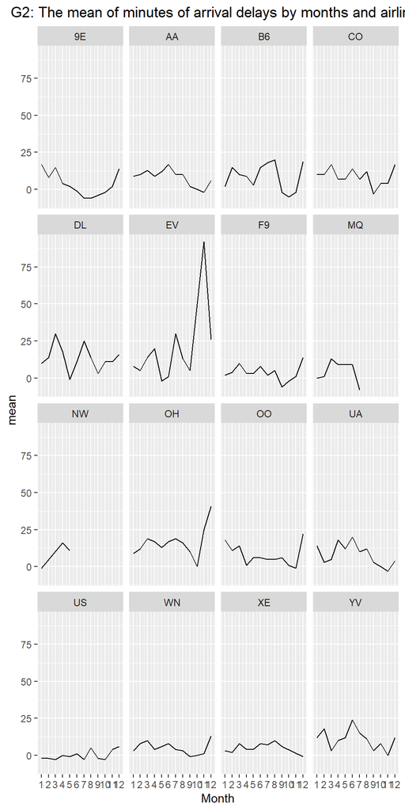

| Month | UniqueCarrier | mean |
| --- | --- | --- |
| 12 | XE | -1 |
| 12 | UA | 4 |
| 12 | AA | 6 |
| 12 | US | 6 |
| 12 | YV | 12 |
| 12 | WN | 13 |

| Month | UniqueCarrier | mean |
| --- | --- | --- |
| 12 | OH | 41 |
| 12 | EV | 26 |
| 12 | OO | 22 |
| 12 | B6 | 19 |
| 12 | CO | 17 |
| 12 | DL | 16 |

It is difficult for us to see the number of arriving delays all month to judge which airline is the best. So ,here, I focus on that of December because the number of arriving delays is highest on December.

### Comment on Graph 2 and Tables:

The Graph 2 shows that the number of arriving delays by months and airlines. The first table says its data by ascending order and the second table do it by decending order.

The fluctiation of most of airlines looks like that of the average one except for some companies, such as EV and DL. The companies with low delays on Decemberare JSX, United Airline and American Airline, and the companies with high delays on Decemberare PSA Airline, Express Jet and SkyWest Airlines.

### Discussion on Graph 2:

United Airlines and American Airlines are very famous and big companies with many planes and flight paths. So if some of the airplanes they have were delayed, they might have another way to avoid delays more than small companies. So, therefore, big firms were better if you wanted to avoid the uncertainty of arrival delays of your air in December.

### Conclusion:

If you want to avoid arrival delays of your air, especially in December when many delays happen, you should choose big firms like United Airlines and American Airlines.

## 2) Wrangling the Olympics

### A) What is the 95th percentile of heights for female competitors across all Athletics events?

```
## 95%
## 183
```

From the result, the answer is **183**

### B) Which single women’s event had the greatest variability in competitor’s heights across the entire history of the Olympics, as measured by the standard deviation?

| event | sd | sex |
| --- | --- | --- |
| Rowing Women’s Coxed Fours | 10.865490 | F |
| Basketball Women’s Basketball | 9.700255 | F |
| Rowing Women’s Coxed Quadruple Sculls | 9.246396 | F |
| Rowing Women’s Coxed Eights | 8.741931 | F |
| Swimming Women’s 100 metres Butterfly | 8.134398 | F |
| Volleyball Women’s Volleyball | 8.101521 | F |

Therefore, the answer is **Rowing Women’s Coxed Fours**.

### c) How has the average age of Olympic swimmers changed over time? Does the trend look different for male swimmers relative to female swimmers?

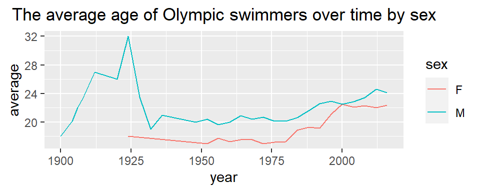

## 3) K-nearest neighbors: cars

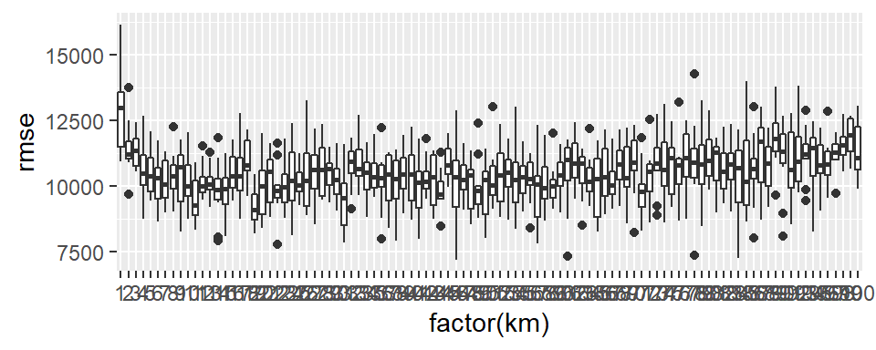

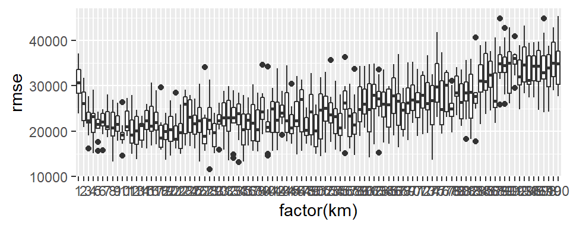

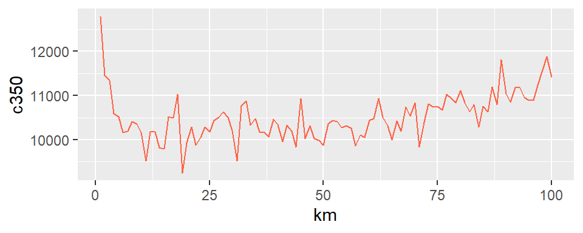

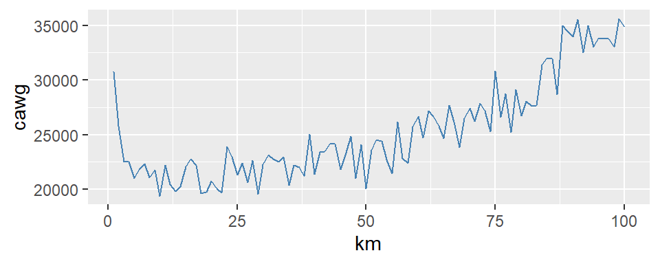

### The fitted model of the 350

```
## [1] 10548.73
```

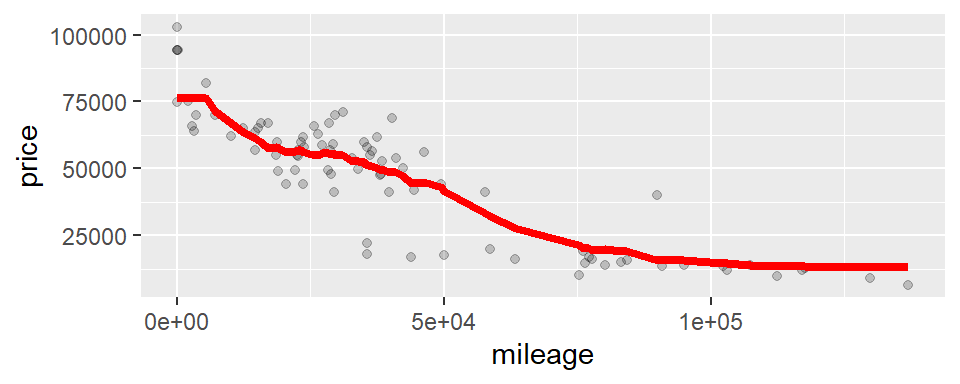